# Activity Analysis

Stephen Hobbs

April 13, 2016

It is now possible to collect a large amount of data about personal movement using activity monitoring devices such as a Fitbit, Nike Fuelband, or Jawbone Up. These type of devices are part of the “quantified self” movement – a group of enthusiasts who take measurements about themselves regularly to improve their health, to find patterns in their behavior, or because they are tech geeks. But these data remain under-utilized both because the raw data are hard to obtain and there is a lack of statistical methods and software for processing and interpreting the data.

This research analyzes the amount of steps taken in five minute intervals throughout a week. It examines mean and median number of steps and asks the question, “When were more average steps taken: weekday or weekend?”

To begin download the data set from this url: https://www.coursera.org/learn/reproducible-research/peer/gYyPt/course-project-1 Click on the hyperlink, “Activity monitoring data.” Download and save to your hard drive. The variables included in this dataset are:

```
steps: Number of steps taking in a 5-minute interval (missing values are coded as NA)
date: The date on which the measurement was taken in YYYY-MM-DD format
interval: Identifier for the 5-minute interval in which measurement was taken
```

The dataset is stored in a comma-separated-value (CSV) file and there are a total of 17,568 observations in this dataset. Loading and preprocessing the data, import .csv file. Assign the variable, data, to the file.

Load R package to be used later.

```r
setwd("/Users/stephenhobbs1/Data science/5-Reproducible Research")
data <- read.csv("activity.csv", stringsAsFactors=FALSE, header = TRUE)
library(plyr)
library(lattice)
```

# What is total number of steps taken?

```r
#Summarize dataframe by date, total steps
tmp<-ddply(data,.(date),summarise, totalSteps=sum(steps, na.rm=TRUE))
# Sum of total steps, 570,608 steps.
sum(tmp$totalSteps)
```

```
## [1] 570608
```

Here is the histogram.

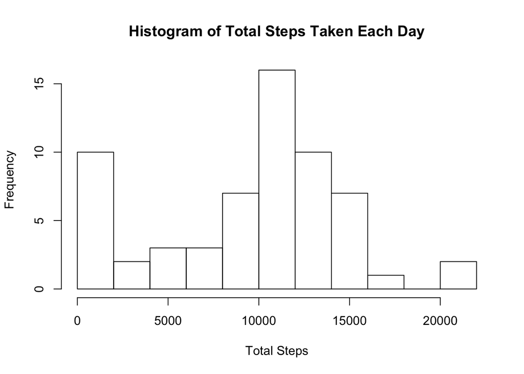

```r
hist(tmp$totalSteps, breaks = 10, xlab = "Total Steps",
     main = "Histogram of Total Steps Taken Each Day")
```

Next is the code of the average and median steps.

```r
# Average step is 9354.23
mean(tmp$totalSteps, na.rm=TRUE)
```

```
## [1] 9354.23
```

```r
# Median step is 10,395
median(tmp$totalSteps, na.rm=TRUE)
```

```
## [1] 10395
```

# What is the average daily activity pattern?

Use the plyr package, ddply function, to get the average steps per time interval and plot. Assign new variable, tmp2, to this data frame.

```r
#Summarize date set by date, average steps/interval
tmp2<-ddply(data,.(interval),summarise, AverageSteps=mean(steps, na.rm=TRUE))
# Average number of steps to use in imputing NA values
mean(tmp2$AverageSteps)
```

```
## [1] 37.3826
```

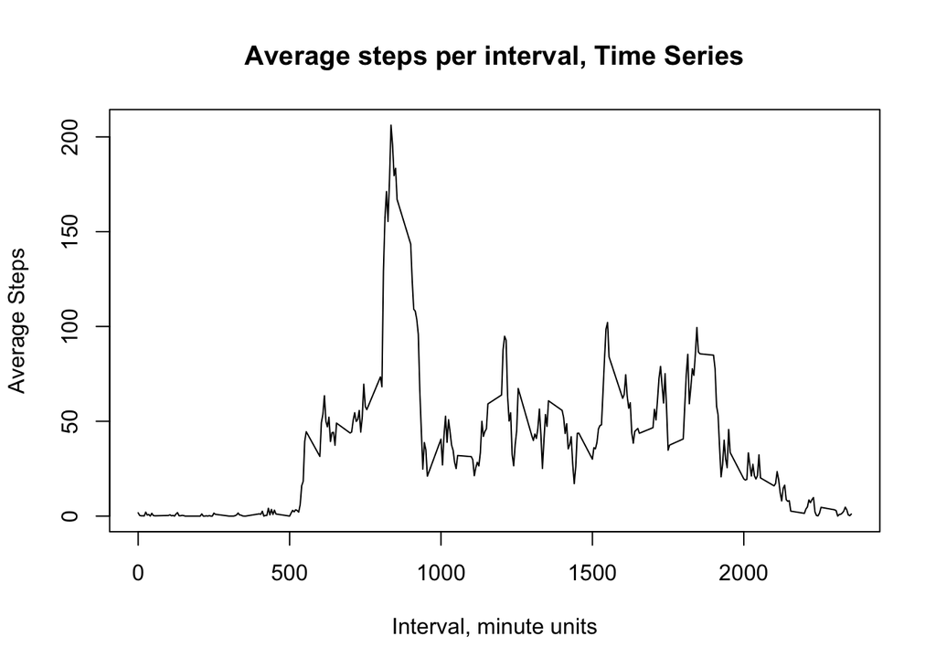

```r
# Plot average steps per interval using a line as the type.
plot(tmp2, type="l", main = "Average steps per interval, Time Series", ylab="Average Steps", xlab="Interval, minute units")
```